# Time of Use Electricity Rate Analysis

```r
#library(rmarkdown)
library(tidyverse)
library(lubridate)
library(hms)
```

Import and examine PPL 15 minute net meter interval data

```r
hourly_ppl_pivot <- read_csv("ppl_15mins.csv")
(hourly_ppl_net <- hourly_ppl_pivot %>%
  filter(`Read Type` == "kWh Net") %>%
  arrange(desc(date)))
```

| date | Read Type | time | kWh |
| --- | --- | --- | --- |
| 2024-08-18 | kWh Net | 00:00:00 | 0.62 |
| 2024-08-18 | kWh Net | 00:15:00 | 0.38 |
| 2024-08-18 | kWh Net | 00:30:00 | 0.13 |
| 2024-08-18 | kWh Net | 00:45:00 | 0.09 |
| 2024-08-18 | kWh Net | 01:00:00 | 0.10 |
| 2024-08-18 | kWh Net | 01:15:00 | 0.10 |
| 2024-08-18 | kWh Net | 01:30:00 | 0.09 |
| 2024-08-18 | kWh Net | 01:45:00 | 0.34 |
| 2024-08-18 | kWh Net | 02:00:00 | 0.10 |
| 2024-08-18 | kWh Net | 02:15:00 | 0.11 |

[output cut: 990 more lines]

Load Enphase data

```r
full_hist <- read_csv("enphase_production.csv")
(hourly_production <- full_hist %>%
  rename(datetime = `Date/Time`, energy_produced_Wh = `Energy Produced (Wh)`) %>%
  mutate(datetime = as.POSIXct(datetime,format="%m/%d/%Y %H:%M",tz=Sys.timezone())) %>%
  mutate(date = date(datetime), time = as.hms(format(datetime, format = "%H:%M:%S")), month = month(datetime, label=TRUE), year = year(datetime), day = day(datetime), yday = yday(datetime), monthday = format(datetime, "%m-%d"), wday = wday(datetime, label=TRUE), equinox_day = (yday + 10) %% 365, equinox_group = floor((equinox_day+15)/30)*30) %>%
    arrange(desc(datetime))
)
```

| ...1 | datetime | energy_produced_Wh | date | time | month | year | day | yday | monthday | wday | equinox_day | equinox_group |
| --- | --- | --- | --- | --- | --- | --- | --- | --- | --- | --- | --- | --- |
| 82368 | 2024-08-19 23:45:00 | 0 | 2024-08-19 | 23:45:00 | Aug | 2024 | 19 | 232 | 08-19 | Mon | 242 | 240 |
| 82367 | 2024-08-19 23:30:00 | 0 | 2024-08-19 | 23:30:00 | Aug | 2024 | 19 | 232 | 08-19 | Mon | 242 | 240 |
| 82366 | 2024-08-19 23:15:00 | 0 | 2024-08-19 | 23:15:00 | Aug | 2024 | 19 | 232 | 08-19 | Mon | 242 | 240 |
| 82365 | 2024-08-19 23:00:00 | 0 | 2024-08-19 | 23:00:00 | Aug | 2024 | 19 | 232 | 08-19 | Mon | 242 | 240 |
| 82364 | 2024-08-19 22:45:00 | 0 | 2024-08-19 | 22:45:00 | Aug | 2024 | 19 | 232 | 08-19 | Mon | 242 | 240 |
| 82363 | 2024-08-19 22:30:00 | 0 | 2024-08-19 | 22:30:00 | Aug | 2024 | 19 | 232 | 08-19 | Mon | 242 | 240 |
| 82362 | 2024-08-19 22:15:00 | 0 | 2024-08-19 | 22:15:00 | Aug | 2024 | 19 | 232 | 08-19 | Mon | 242 | 240 |
| 82361 | 2024-08-19 22:00:00 | 0 | 2024-08-19 | 22:00:00 | Aug | 2024 | 19 | 232 | 08-19 | Mon | 242 | 240 |
| 82360 | 2024-08-19 21:45:00 | 0 | 2024-08-19 | 21:45:00 | Aug | 2024 | 19 | 232 | 08-19 | Mon | 242 | 240 |
| 82359 | 2024-08-19 21:30:00 | 0 | 2024-08-19 | 21:30:00 | Aug | 2024 | 19 | 232 | 08-19 | Mon | 242 | 240 |

[output cut: 990 more lines]

Net + Produced = Consumed Start and End Dates of electricity data

```r
(hourly_electricity <- hourly_ppl_net %>%
    inner_join(hourly_production, by = join_by(date,time))  %>%
    mutate(consumed_kWh = kWh + energy_produced_Wh/1000, produced_kWh = energy_produced_Wh/1000)  %>%
    rename(net_kWh = kWh) %>%
    select(datetime, date, time, net_kWh, produced_kWh, consumed_kWh) %>%
    arrange(desc(datetime)))
```

| datetime | date | time | net_kWh | produced_kWh | consumed_kWh |
| --- | --- | --- | --- | --- | --- |
| 2024-08-18 23:45:00 | 2024-08-18 | 23:45:00 | 0.15 | 0.000 | 0.150 |
| 2024-08-18 23:30:00 | 2024-08-18 | 23:30:00 | 0.13 | 0.000 | 0.130 |
| 2024-08-18 23:15:00 | 2024-08-18 | 23:15:00 | 0.14 | 0.000 | 0.140 |
| 2024-08-18 23:00:00 | 2024-08-18 | 23:00:00 | 0.27 | 0.000 | 0.270 |
| 2024-08-18 22:45:00 | 2024-08-18 | 22:45:00 | 0.42 | 0.000 | 0.420 |
| 2024-08-18 22:30:00 | 2024-08-18 | 22:30:00 | 0.12 | 0.000 | 0.120 |
| 2024-08-18 22:15:00 | 2024-08-18 | 22:15:00 | 0.23 | 0.000 | 0.230 |
| 2024-08-18 22:00:00 | 2024-08-18 | 22:00:00 | 0.49 | 0.000 | 0.490 |
| 2024-08-18 21:45:00 | 2024-08-18 | 21:45:00 | 0.13 | 0.000 | 0.130 |
| 2024-08-18 21:30:00 | 2024-08-18 | 21:30:00 | 0.34 | 0.000 | 0.340 |

[output cut: 990 more lines]

```r
hourly_electricity %>%
  summarize(min(date), max(date))
```

| min(date) | max(date) |
| --- | --- |
| 2022-04-15 | 2024-08-18 |

```r
NA
```

Cost of fixed rate electricity over the full period.

```r
fixed_rate <- 0.1004 + 0.04727 #PA average electricity rate, supply + delivery charges combined

hourly_electricity %>%
  mutate(net_fixed = net_kWh * fixed_rate, consumed_fixed = consumed_kWh * fixed_rate) %>%
  #group_by(year(date), month(date)) %>%
  summarize(produced_kWh = sum(produced_kWh), consumed_kWh = sum(consumed_kWh), net_fixed_cost = sum(net_fixed), consumed_fixed_cost = sum(consumed_fixed))
```

| produced_kWh | consumed_kWh | net_fixed_cost | consumed_fixed_cost |
| --- | --- | --- | --- |
| 43586.17 | 36767.96 | -1006.845 | 5429.525 |

```r
NA
```

Peak vs. Off-peak consumption/production

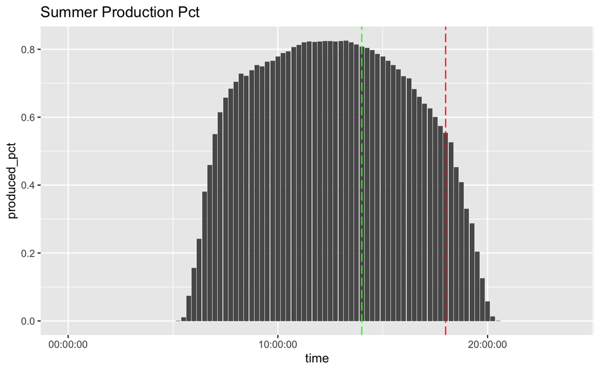

```r
electricity_by_time_jun_nov <- hourly_electricity %>%
  filter(month(date) %in% c(6,7,8,9,10,11)) %>%
  group_by(time) %>%
  summarize(produced_kWh = sum(produced_kWh), consumed_kWh = sum(consumed_kWh), net_kWh = sum(consumed_kWh) - sum(produced_kWh)) %>%
  mutate(produced_pct = produced_kWh/(consumed_kWh+produced_kWh))

ggplot(electricity_by_time_jun_nov, aes(x = time, y = produced_pct)) +
  geom_bar(stat="identity") +
  geom_vline(xintercept = as_hms("14:00:00"), colour="green", linetype = "longdash") +
  geom_vline(xintercept = as_hms("18:00:00"), colour="red", linetype = "longdash") +
  ggtitle("Summer Production Pct")
```

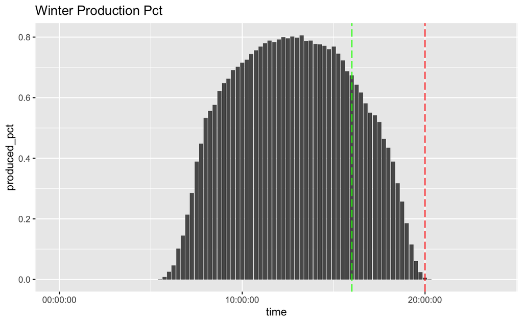

```r
electricity_by_time_dec_may <- hourly_electricity %>%
  filter(month(date) %in% c(12,1,2,3,4,5)) %>%
  group_by(time) %>%
  summarize(produced_kWh = sum(produced_kWh), consumed_kWh = sum(consumed_kWh), net_kWh = sum(consumed_kWh) - sum(produced_kWh)) %>%
  mutate(produced_pct = produced_kWh/(consumed_kWh+produced_kWh))

ggplot(electricity_by_time_dec_may, aes(x = time, y = produced_pct)) +
  geom_bar(stat="identity") +
  geom_vline(xintercept = as_hms("16:00:00"), colour="green", linetype = "longdash") +
  geom_vline(xintercept = as_hms("20:00:00"), colour="red", linetype = "longdash") +
  ggtitle("Winter Production Pct")
```

```r
#monthly totals by peak/off-peak
peak_off_peak_electricity_by_month <- hourly_electricity %>%
  mutate(year = year(date), month = month(date), year_month = format(date,"%Y-%m"),
    category = case_when(wday(datetime) %in% c(1,7) ~ "off_peak", #weekends
                                   hour(datetime) >= 14 & hour(datetime) < 18 & month(datetime) %in% c(6,7,8,9,10,11) ~ "peak", #JuneToNovPeak
                                   hour(datetime) >= 16 & hour(datetime) < 20 & month(datetime) %in% c(12,1,2,3,4,5) ~ "peak", #DecToMayPeak
                                   .default = "off_peak"
                                   )
         ) %>%
  group_by(year, month, year_month, category) %>%
  summarize(produced_kWh = sum(produced_kWh), consumed_kWh = sum(consumed_kWh), net_kWh = sum(consumed_kWh) - sum(produced_kWh)) %>%
  arrange(year, month)
peak_off_peak_electricity_by_month
```

| year | month | year_month | category | produced_kWh | consumed_kWh | net_kWh |
| --- | --- | --- | --- | --- | --- | --- |
| 2022 | 4 | 2022-04 | off_peak | 888.876 | 370.646 | -518.23 |
| 2022 | 4 | 2022-04 | peak | 114.895 | 50.065 | -64.83 |
| 2022 | 5 | 2022-05 | off_peak | 1699.889 | 673.489 | -1026.40 |
| 2022 | 5 | 2022-05 | peak | 294.571 | 111.151 | -183.42 |
| 2022 | 6 | 2022-06 | off_peak | 1722.783 | 996.273 | -726.51 |
| 2022 | 6 | 2022-06 | peak | 556.965 | 206.465 | -350.50 |
| 2022 | 7 | 2022-07 | off_peak | 1737.851 | 1069.711 | -668.14 |
| 2022 | 7 | 2022-07 | peak | 499.266 | 249.786 | -249.48 |
| 2022 | 8 | 2022-08 | off_peak | 1575.873 | 1285.143 | -290.73 |
| 2022 | 8 | 2022-08 | peak | 575.877 | 270.527 | -305.35 |

[output cut: 48 more lines]

```r
#peak/offpeak totals
peak_off_peak_electricity <- peak_off_peak_electricity_by_month %>%
  group_by(category) %>%
  summarize(produced_kWh = sum(produced_kWh), consumed_kWh = sum(consumed_kWh), net_kWh = sum(consumed_kWh) - sum(produced_kWh))

peak_off_peak_electricity %>%
  summarize(produced_off_peak = sum(case_when(category=="off_peak" ~ produced_kWh, .default = 0)),
         produced_peak = sum(case_when(category=="peak" ~ produced_kWh, .default = 0)),
         consumed_off_peak = sum(case_when(category=="off_peak" ~ consumed_kWh, .default = 0)),
         consumed_peak = sum(case_when(category=="peak" ~ consumed_kWh, .default = 0)),
         net_off_peak = sum(case_when(category=="off_peak" ~ net_kWh, .default = 0)),
         net_peak = sum(case_when(category=="peak" ~ net_kWh, .default = 0)),
         ) %>%
  mutate(produced_peak_pct = produced_peak/(produced_peak+produced_off_peak),
         consumed_peak_pct = consumed_peak/(consumed_peak+consumed_off_peak))
```

| produced_off_peak | produced_peak | consumed_off_peak | consumed_peak | net_off_peak | net_peak | produced_peak_pct | consumed_peak_pct |
| --- | --- | --- | --- | --- | --- | --- | --- |
| 35333.67 | 8252.499 | 31979.75 | 4788.209 | -3353.92 | -3464.29 | 0.1893376 | 0.1302278 |

```r
#by month pivot
peak_off_peak_electricity_by_month_pivot <- peak_off_peak_electricity_by_month %>%
  group_by(year, month, year_month) %>%
  summarize(produced_off_peak = sum(case_when(category=="off_peak" ~ produced_kWh, .default = 0)),
         produced_peak = sum(case_when(category=="peak" ~ produced_kWh, .default = 0)),
         consumed_off_peak = sum(case_when(category=="off_peak" ~ consumed_kWh, .default = 0)),
         consumed_peak = sum(case_when(category=="peak" ~ consumed_kWh, .default = 0)),
         net_off_peak = sum(case_when(category=="off_peak" ~ net_kWh, .default = 0)),
         net_peak = sum(case_when(category=="peak" ~ net_kWh, .default = 0)),
         ) %>%
  mutate(produced_peak_pct = produced_peak/(produced_peak+produced_off_peak),
         consumed_peak_pct = consumed_peak/(consumed_peak+consumed_off_peak))
peak_off_peak_electricity_by_month_pivot
```

| year | month | year_month | produced_off_peak | produced_peak | consumed_off_peak | consumed_peak | net_off_peak | net_peak | produced_peak_pct | consumed_peak_pct |
| --- | --- | --- | --- | --- | --- | --- | --- | --- | --- | --- |
| 2022 | 4 | 2022-04 | 888.876 | 114.895 | 370.646 | 50.065 | -518.23 | -64.83 | 0.11446336 | 0.11900093 |
| 2022 | 5 | 2022-05 | 1699.889 | 294.571 | 673.489 | 111.151 | -1026.40 | -183.42 | 0.14769461 | 0.14165860 |
| 2022 | 6 | 2022-06 | 1722.783 | 556.965 | 996.273 | 206.465 | -726.51 | -350.50 | 0.24430990 | 0.17166249 |
| 2022 | 7 | 2022-07 | 1737.851 | 499.266 | 1069.711 | 249.786 | -668.14 | -249.48 | 0.22317384 | 0.18930395 |
| 2022 | 8 | 2022-08 | 1575.873 | 575.877 | 1285.143 | 270.527 | -290.73 | -305.35 | 0.26763193 | 0.17389742 |
| 2022 | 9 | 2022-09 | 1202.503 | 430.147 | 890.483 | 153.457 | -312.02 | -276.69 | 0.26346553 | 0.14699791 |
| 2022 | 10 | 2022-10 | 914.057 | 262.462 | 937.017 | 111.972 | 22.96 | -150.49 | 0.22308352 | 0.10674278 |
| 2022 | 11 | 2022-11 | 740.625 | 169.090 | 1187.365 | 149.350 | 446.74 | -19.74 | 0.18587140 | 0.11172913 |
| 2022 | 12 | 2022-12 | 659.016 | 7.685 | 1891.286 | 265.565 | 1232.27 | 257.88 | 0.01152691 | 0.12312626 |
| 2023 | 1 | 2023-01 | 540.574 | 12.694 | 1646.674 | 207.264 | 1106.10 | 194.57 | 0.02294367 | 0.11179662 |

[output cut: 19 more lines]

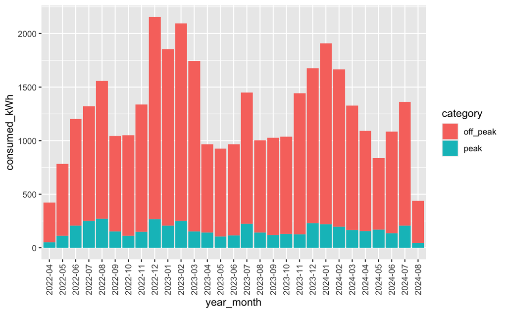

```r
#Plot peak usage by month
ggplot(peak_off_peak_electricity_by_month, aes(x = year_month, y = consumed_kWh, fill = category)) +
  geom_bar(stat="identity") +
  theme(axis.text.x = element_text(angle = 90, vjust = 0.5, hjust=1))
```

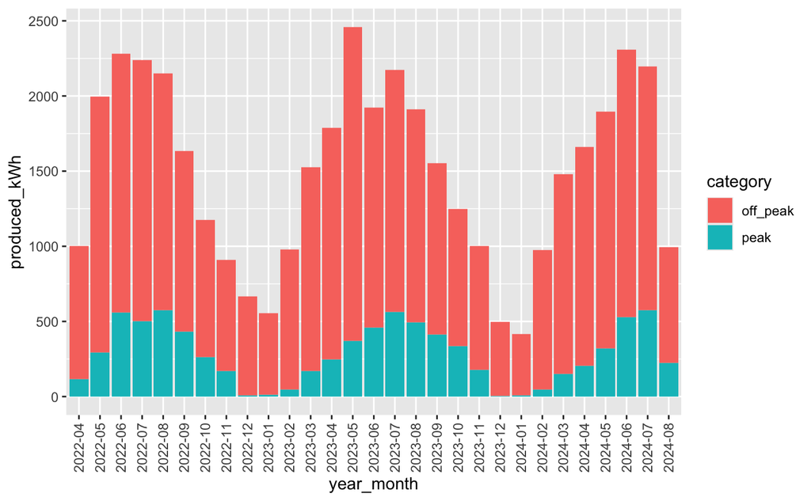

```r
ggplot(peak_off_peak_electricity_by_month, aes(x = year_month, y = produced_kWh, fill = category)) +
  geom_bar(stat="identity") +
  theme(axis.text.x = element_text(angle = 90, vjust = 0.5, hjust=1))
```

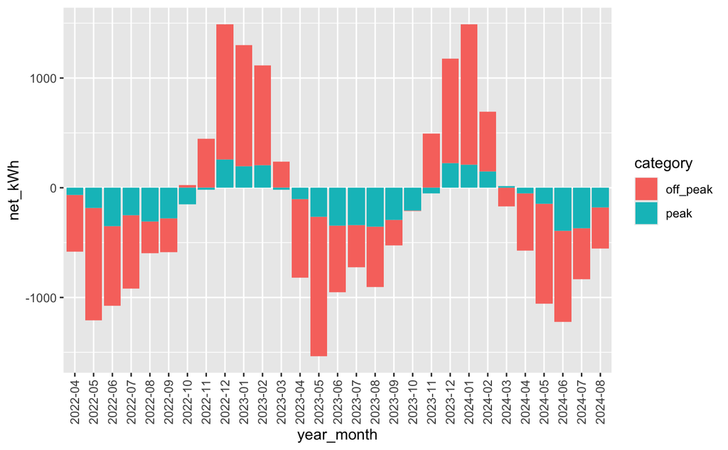

```r
ggplot(peak_off_peak_electricity_by_month, aes(x = year_month, y = net_kWh, fill = category)) +
  geom_bar(stat="identity") +
  theme(axis.text.x = element_text(angle = 90, vjust = 0.5, hjust=1))
```

```r
NA
NA
```

Time of Use rate cost over the full period

Step 1: Usage totaled We total your usage and generation by each season. If you generated more than you used, we’ll add these to your bank. You’ll still receive a bill for basic service. If you used more than you generated, we move to Step 2. - Might have to go back and group by season as well as month/year

Step 2: Current bill In the same bill cycle, you may have usage to offset in one season or time period, and excess generation in another. If this is the case, we use your excess generation first to offset any usage you would be billed for.

Step 3: Bank applied If you still have usage you would be billed for, we pull any existing or previously banked hours to offset your bill. Banked hours are used chronologically. You will be billed for any kilowatt-hours used above your banked amount.

How is my bank used? If you generate more than you use, you’ll bank kilowatt-hours at seasonal on- and off-peak rates. Then if there is a month when you use more than you generate, we’ll use some of those banked hours to offset your energy costs.

Here is how we use your bank to offset your usage:

Banked hours are used chronologically. For example, June’s off-peak hours would be used first, then June’s on-peak hours. Your usage is also offset chronologically. We offset your oldest on-peak hours first. Then your oldest off-peak hours.

```r
#https://www.pplelectric.com/my-account/shop-for-electricity/time-of-use-plan/tou-enrollment
peak_rate <- 0.12936 + 0.04727
off_peak_rate <- 0.09319 + 0.04727

#write_csv(peak_off_peak_electricity_by_month_pivot, "peak_off_peak_electricity_by_month_pivot.csv")

df <- peak_off_peak_electricity_by_month_pivot %>%
  rowid_to_column(var='row_id') %>%
  mutate(cum_off_peak_bank = 0, cum_peak_bank = 0) %>%
  ungroup() %>%
  slice_min(row_id, n=15)

#set variables net, net_peak, net_off_peak, peak_bank, off_peak_bank
net <- 0
net_peak <- 0
net_off_peak <- 0
peak_bank <- 0
off_peak_bank <- 0

i = 1

while(i <= nrow(df)) {

  #print(i)

  #pull net kWh values from this month
  net_peak <- pull(df %>% filter(row_id == i) %>% select(net_peak))
  net_off_peak <- pull(df %>% filter(row_id == i) %>% select(net_off_peak))
  net <- net_peak + net_off_peak

  if (net <= 0) {
    if (net_peak <= 0 & net_off_peak <= 0) {
      peak_bank = peak_bank + net_peak
      off_peak_bank = off_peak_bank + net_off_peak
    }
    else if (net_peak <= 0 & net_off_peak > 0) {
      peak_bank = peak_bank + net
    }
    else if (net_off_peak <= 0 & net_peak > 0) {
      off_peak_bank = off_peak_bank + net
    }
  } else if (net > 0) {
    if (net_peak > 0 & net_off_peak > 0) {
      peak_bank = peak_bank + net_peak
      off_peak_bank = off_peak_bank + net_off_peak
    } else if (net_peak <= 0 & net_off_peak > 0) {
      off_peak_bank = off_peak_bank + net
    } else if (net_off_peak <= 0 & net_peak > 0) {
      peak_bank = peak_bank + net
    }
  } else if (off_peak_bank > 0 & peak_bank > 0) {
    #charge customer for each and reset to 0
    #fix these
    #df <- df %>% filter(row_id == i) %>% mutate(peak_charge = peak_rate*peak_bank)
    #df <- df %>% filter(row_id == i) %>% mutate(off_peak_charge = off_peak_rate*off_peak_bank)
    peak_bank <- 0
    off_peak_bank <- 0
  } else if (peak_bank > 0) {
    #charge the customer and reset to 0
    df <- df %>% filter(row_id == i) %>% mutate(peak_charge = peak_rate*peak_bank)
    peak_bank <- 0
    off_peak_bank <- 0
  }

  df <- rows_update(df, tibble(row_id = i, cum_off_peak_bank = off_peak_bank, cum_peak_bank = peak_bank), by = "row_id")
  #df$peak_bank <- peak_bank
  #df$off_peak_bank <- off_peak_bank

  #split by season (summer/winter)

  #if month == 5, then charge the customer and reset to 0
  #peak_bank <- 0
  #off_peak_bank <- 0

  i = i + 1
}

df
```

| row_id | year | month | year_month | produced_off_peak | produced_peak | consumed_off_peak | consumed_peak | net_off_peak | net_peak | produced_peak_pct | consumed_peak_pct | cum_off_peak_bank | cum_peak_bank |
| --- | --- | --- | --- | --- | --- | --- | --- | --- | --- | --- | --- | --- | --- |
| 1 | 2022 | 4 | 2022-04 | 888.876 | 114.895 | 370.646 | 50.065 | -518.23 | -64.83 | 0.11446336 | 0.11900093 | -518.23 | -64.83 |
| 2 | 2022 | 5 | 2022-05 | 1699.889 | 294.571 | 673.489 | 111.151 | -1026.40 | -183.42 | 0.14769461 | 0.14165860 | -1544.63 | -248.25 |
| 3 | 2022 | 6 | 2022-06 | 1722.783 | 556.965 | 996.273 | 206.465 | -726.51 | -350.50 | 0.24430990 | 0.17166249 | -2271.14 | -598.75 |
| 4 | 2022 | 7 | 2022-07 | 1737.851 | 499.266 | 1069.711 | 249.786 | -668.14 | -249.48 | 0.22317384 | 0.18930395 | -2939.28 | -848.23 |
| 5 | 2022 | 8 | 2022-08 | 1575.873 | 575.877 | 1285.143 | 270.527 | -290.73 | -305.35 | 0.26763193 | 0.17389742 | -3230.01 | -1153.58 |
| 6 | 2022 | 9 | 2022-09 | 1202.503 | 430.147 | 890.483 | 153.457 | -312.02 | -276.69 | 0.26346553 | 0.14699791 | -3542.03 | -1430.27 |
| 7 | 2022 | 10 | 2022-10 | 914.057 | 262.462 | 937.017 | 111.972 | 22.96 | -150.49 | 0.22308352 | 0.10674278 | -3542.03 | -1557.80 |
| 8 | 2022 | 11 | 2022-11 | 740.625 | 169.090 | 1187.365 | 149.350 | 446.74 | -19.74 | 0.18587140 | 0.11172913 | -3115.03 | -1557.80 |
| 9 | 2022 | 12 | 2022-12 | 659.016 | 7.685 | 1891.286 | 265.565 | 1232.27 | 257.88 | 0.01152691 | 0.12312626 | -1882.76 | -1299.92 |
| 10 | 2023 | 1 | 2023-01 | 540.574 | 12.694 | 1646.674 | 207.264 | 1106.10 | 194.57 | 0.02294367 | 0.11179662 | -776.66 | -1105.35 |

[output cut: 5 more lines]

```r
NA
```

Details to come back to:

```r
#add holidays to off_peak
  # New Year's Day
  # Presidents Day
  # Good Friday
  # Memorial Day
  # Independence Day
  # Labor Day
  # Thanksgiving Day
  # Day after Thanksgiving
  # Christmas Eve
  # Christmas Day

#separate seasons (even within a bill)

#account for rate changes
```

If TOU rate applied hourly (N/A):

What if we shifted the EV charging load? - Detect EV charging load - Give it the lower rate

Load Emporia charging 15 minute interval data

Check date range for available hourly charging data

Run fixed and variable rates on those dates Fixed rate cost on this date range.

TOU cost for this date range

Shift EV charging to lower rate

Plot of energy usage by hour - Split by months

EV charging by hour

Load without charging

Plot of peak/off peak energy usage (stacked bar chart?) - Same plot with shifted load - Split by months

On peak vs off peak kWh by day/month

Charging by time of day? Winter vs. summer?

Plot of my average energy usage in “summer” vs. “winter”

plot of energy cost by day on each plan. - Total by month